# TP3 Systèmes de Recommandations

Corentin Lacroix, Léa Boisdur

20 novembre 2016

## 0. Utility functions and data integration

```r
library(Matrix)
library(RCurl)
#0.a Utiliy functions
cosinus.m <- function(m) {
  ans <- t(m) %*% m
  m.norms <- sqrt(colSums(m^2, na.rm=TRUE))
  ans <- ans/m.norms
  ans <- ans %*% diag(1/m.norms)
  return(ans)
  }

u.data <- read.csv(file='./data/u.data.csv', sep='|', header=T)
m <- sparseMatrix(u.data[,1],u.data[,2],x=u.data[,3])
rownames(m) <- paste('u', 1:nrow(m), sep='')
colnames(m) <- paste('i', 1:ncol(m), sep='')
m <- as.matrix(m)
p <- dim(m)[1] # Number of users
n <- dim(m)[2] # Number of items

## Construct matrices equivalent to m with NAs
m.na <- m
m.na[m==0] <- NA
```

## 1. Point de comparaison pour la prédiction des votes

Nous avons testé pour cette question 2 méthodes : - pour chaque couple (u,i), la prédiction du rating correspondant est la moyenne des votes donnés par l’utilisateur u - pour chaque couple (u,i), la prédiction du rating correspondant est la moyenne des votes donnés à l’item i

Nous avons testé ces méthodes par Cross Validation pour obtenir des estimateurs non biaisées des performances. Une subtilité apparait dans ce cas la : certains items/users ont peu de votes ; ainsi le fait de retirer certaines observations peut empecher le calcul de la moyenne des votes (par user ou item) car il n’y a plus d’observations. Certaines ratings du test set ne peuvent ainsi être prédits.

La méthode basée sur la moyenne des votes données à l’item semble légèrement meilleure.

```r
# 1. Implement a naïve vote prediction methods and estimate rmse mae by cross validation :
# a. cv_av_colmean : Set predicted rating for (user, item) to item average given rating

# Construct array indices containing couples (indices[k,1], indices[k,2]) for which a rating was observed.
indices <- which(m >= 1, arr.ind=T)
indices <- indices[sample(nrow(indices)),]
n_fold <- 5

cv_av_colmean <- function(m, n_fold, observations) {

  n_obs <- nrow(observations)
  fold_size = n_obs %/% n_fold
  mae <- 0
  rmse <- 0

  # Compute columns means vector and na indices
  na_obs <- which(is.na(m), arr.ind=TRUE)

  for (k in seq(0, n_fold-1)) {

    print(paste("Computing Error for test set ", toString(k+1)))
    test_obs <- observations[seq(k*fold_size, ((k + 1) * fold_size - 1)),]
    train_obs <- observations[-seq(k*fold_size, ((k + 1) * fold_size - 1)),]

    # Compute items means with train observations only
    # (ratings for test observations are set to NAN and not taken into account in average computation)
    m_train <- m
    m_train[test_obs] <- NA
    cM <- colMeans(m_train, na.rm=TRUE)

    # Compute matrix cotaining predicted vote (if possible) for test observations
    # and NAN values for all others (train observations, unobserved ratings, test observations
    # that couldn't be predicted because absence of corresponding item average rating)
    m_test.pred <- m
    m_test.pred[test_obs] <- cM[test_obs[,2]] # Set all test ratings to items means in the train matrix
    m_test.pred[train_obs] <- NA # Set all train ratings to NA in this prediction matrix

    # Compute number of effective predictions, mae and rmse
    n_pred_votes <- length(m) - sum(colSums(is.na(m-m_test.pred), na.rm=TRUE))
    mae <- mae + sum(colSums(abs(m - m_test.pred), na.rm = TRUE))/n_pred_votes
    rmse <- rmse + sqrt(sum(colSums((m - m_test.pred)^2, na.rm = TRUE))/n_pred_votes)
  }

  mae <- mae/n_fold
  rmse <- rmse/n_fold

  # Free memory
  rm(m_train)
  rm(m_test.pred)

  return(list(mae_er=mae, rmse_er=rmse))
}

naive_errors_colmean <- cv_av_colmean(m.na, 5, indices)
```

```
## [1] "Computing Error for test set  1"
## [1] "Computing Error for test set  2"
## [1] "Computing Error for test set  3"
## [1] "Computing Error for test set  4"
## [1] "Computing Error for test set  5"
```

```r
print(paste("RMSE is ", naive_errors_colmean$rmse_er))
```

```
## [1] "RMSE is  1.02289637458152"
```

```r
print(paste("MAE is ", naive_errors_colmean$mae_er))
```

```
## [1] "MAE is  0.816028802968635"
```

```r
# b. cv_av_rowmean Set predicted rating for (user, item) to user average rating

cv_av_rowmean <- function(m, n_fold, observations) {

  n_obs <- nrow(observations)
  fold_size = n_obs %/% n_fold
  mae <- 0
  rmse <- 0

  # Compute columns means vector and na indices
  na_obs <- which(is.na(m), arr.ind=TRUE)

  for (k in seq(0, n_fold-1)) {

    print(paste("Computing Error for test set ", toString(k+1)))
    test_obs <- observations[seq(k*fold_size, ((k + 1) * fold_size - 1)),]
    train_obs <- observations[-seq(k*fold_size, ((k + 1) * fold_size - 1)),]

    # Compute items means with train observations only
    # (ratings for test observations are set to NAN and not taken into account in average computation)
    m_train <- m
    m_train[test_obs] <- NA
    cR <- rowMeans(m_train, na.rm=TRUE)

    # Compute matrix cotaining predicted vote (if possible) for test observations
    # and NAN values for all others (train observations, unobserved ratings, test observations
    # that couldn't be predicted because absence of corresponding user average rating)
    m_test.pred <- m
    m_test.pred[test_obs] <- cR[test_obs[,1]] # Set all test ratings to items means in the train matrix
    m_test.pred[train_obs] <- NA # Set all train ratings to NA in this prediction matrix

    # Compute number of effective predictions, mae and rmse
    n_pred_votes <- length(m) - sum(colSums(is.na(m-m_test.pred), na.rm=TRUE))
    mae <- mae + sum(colSums(abs(m - m_test.pred), na.rm = TRUE))/n_pred_votes
    rmse <- rmse + sqrt(sum(colSums((m - m_test.pred)^2, na.rm = TRUE))/n_pred_votes)
  }

  mae <- mae/n_fold
  rmse <- rmse/n_fold

  # Free memory
  rm(m_train)
  rm(m_test.pred)

  return(list(mae_er=mae, rmse_er=rmse))
}

naive_errors_rowmean <- cv_av_rowmean(m.na, 5, indices)
```

```
## [1] "Computing Error for test set  1"
## [1] "Computing Error for test set  2"
## [1] "Computing Error for test set  3"
## [1] "Computing Error for test set  4"
## [1] "Computing Error for test set  5"
```

```r
print(paste("RMSE is ", naive_errors_rowmean$rmse_er))
```

```
## [1] "RMSE is  1.04199185389243"
```

```r
print(paste("MAE is ", naive_errors_rowmean$mae_er))
```

```
## [1] "MAE is  0.835055935300743"
```

## 2,3,4. Appliquer la décomposition SVD

Pour cette question et certaines suivantes, il était demandé de normaliser les données. Nous avons dans un premier temps pensé à normaliser les colonnes/lignes afin que celles-ci aient une moyenne de 0 et variance de 1 (scaling) mais cela revient alors à appliquer la méthode PCA (Principal Component Analysis) et après discussion nous avons su que cette opération n’était pas nécessaire. Par ailleurs, appliquer une normalisation linéaire des données afin que les ratings soient compris entre 0 et 1 ou -1 et 1 ne changent en rien les résultats de la décomposition (mais peuvent influencer les calculs). Pour les questions suivantes (cross validation), ce que nous avons fait revient indirectement à transformer les données afin que celles-ci aient une moyenne de 0 et leur appliquer svd.

```r
# Svd decomposition with k = min(n,p)
m.svd <- svd(m)
```

La méthode SVD native de R ne peut appliquer la décomposition qu’aux matrices numériques sans valeurs nulles. Il nous a donc fallu faire un choix concernant le remplissage des valeurs nulles de la matrice UI. Ici, nous avons choisi de modifier légèrement la matrice à laquelle est appliquée la décomposition SVD : nous remplissons artificiellement les valeurs nulles (ratings non observés) de la matrice UI des votes par les moyennes des colonnes (la méthode de la moyenne des colonnes ou item s’est avérée meilleure lors de la question 1). Nous nous sommes rendus compte que cette méthode (comme précisé dans l’article de Sarwar et al. 2000) permettait d’améliorer drastiquement les performances de la méthode SVD.

D’après la littérature, ceci n’est pas la meilleure méthode pour estimer des votes à partir de la décomposition SVD mais en constitue seulement la première étape. En effet, il faudrait ensuite réappliquer la décomposition SVD à la matrice recomposée et répéter itérativement cette opération jusqu’à convergence (m et sa recomposition svd sont identiques). Ceci ressemble fortement à l’algorithme EM. Nous n’avons pas implémenté cette méthode car complexe et très largement hors du périmètre de ce TP.

Pour estimer les votes en utilisant seulement 10 facteurs latents, il faut reconstruire la matrice initiale à partir de troncatures des matrices u, v et d. Il faut ensuite ramener ces votes dans l’intervalle [0,5]. Le calcul des grandeurs rmse et mae est alors possible. Les estimations des performances des modèles sont ici biaisées et optimistes : l’erreur est calculée d’après les observations qui ont permis d’entrainer le modèle.

```r
# We compute NA observations in m.na matrix and set its unobserved ratings to
# the columns average (item average observed ratings)
na_obs <- which(is.na(m.na), arr.ind=TRUE)
cM <- colMeans(m.na, na.rm=TRUE)
m.normalized <- m.na
m.normalized[na_obs] <-cM[na_obs[,2]]

# SVD decomposition with k = 10
m.svd.10 <- svd(m.normalized, nu=10, nv=10)

# Compute reconstruction of m
m.reconstructed <- m.svd.10$u %*% diag(m.svd.10$d[1:10]) %*% t(m.svd.10$v)

# Scale result to [0,5]
m.reconstructed[m.reconstructed > 5] <- 5
m.reconstructed[m.reconstructed < 0] <- 0

# Compute absolute Mean Error and RMSE
n_votes <- sum(colSums(ifelse(m == 0,0,1)))
mae <- sum(colSums(abs(m.na - m.reconstructed), na.rm = TRUE))/n_votes
rmse <- sqrt(sum(colSums((m.na - m.reconstructed)^2, na.rm = TRUE))/n_votes)
print(paste("RMSE is ", rmse))
```

```
## [1] "RMSE is  0.882912653270213"
```

```r
print(paste("MAE is ", mae))
```

```
## [1] "MAE is  0.696688418791367"
```

## 5. Déterminez le nombre de dimensions optimal sans Cross Validation

Théoriquement, plus la complexité du modèle (ici le nombre de dimensions utilisées dans la reconstruction) est importante, plus l’estimation de l’erreur moyenne du modèle sur l’ensemble d’entrainement sera faible. L’estimation de l’erreur moyenne sur un ensemble de test sera importante lorsque la complexité du modèle est faible (underfitting), importante lorsque la complexité du modèle est grande (overfitting) et minimale pour une “bonne” complexité.

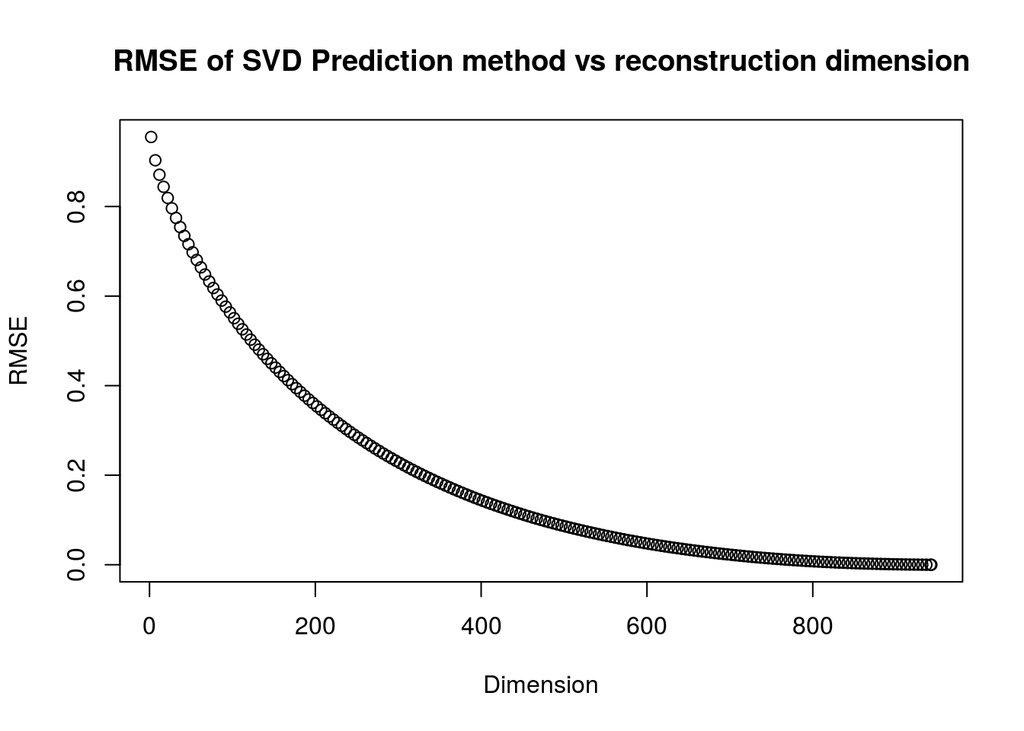

```r
dims <- append(seq(2,min(n,p),5), c(min(n,p)))
m.svd <- svd(m.normalized)

rmse_vec <- rep(0,length(dims))
abser_vec <- rep(0,length(dims))

for (k in c(1:length(dims))) {
  dim = dims[k]
  m.reconstructed <- m.svd$u[,1:dim] %*% diag(m.svd$d[1:dim]) %*% t(m.svd$v[,1:dim]) # reconstruct original matrix

  # Scale votes to [1,5]
  m.reconstructed[m.reconstructed > 5] <- 5
  m.reconstructed[(m.reconstructed < 1) & (m.reconstructed > 0)] <- 1

  # Compute MAE and RMSE
  abser_vec[k] <- sum(colSums(abs(m.na - m.reconstructed), na.rm = TRUE))/n_votes
  rmse_vec[k] <- sqrt(sum(colSums((m.na - m.reconstructed)^2, na.rm = TRUE))/n_votes)
}

plot(dims, rmse_vec, main="RMSE of SVD Prediction method vs reconstruction dimension", ylab="RMSE", xlab="Dimension")
```

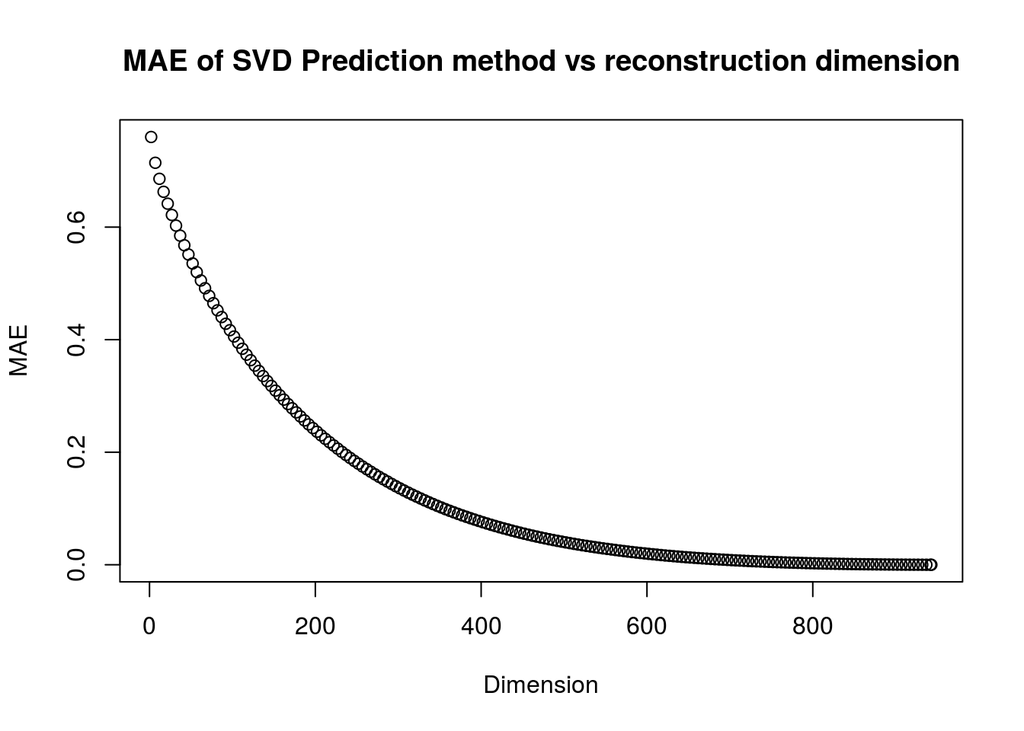

```r
plot(dims, abser_vec, main="MAE of SVD Prediction method vs reconstruction dimension", ylab="MAE", xlab="Dimension")
```

Sans surprises, plus la complexité du modèle est importante, plus l’estimation utilisée ici de l’erreur est faible. Elle est même de 0 pour la complexité maximale : la matrice est alors parfaitement reconstituée.

## 6. Estimation des erreurs par Cross Validation

```r
cv_svd_colmean <- function(m, n_fold, observations, dims) {

  n_obs <- nrow(observations)
  fold_size = n_obs %/% n_fold
  rmse_vec <- rep(0, length(dims))
  abser_vec <- rep(0, length(dims))

  # Compute columns means vector and na indices
  na_obs <- which(is.na(m), arr.ind=TRUE)

  for (k in seq(0, n_fold-1)) {

    print(paste("Computing Error for test set ", toString(k+1)))
    test_obs <- observations[seq(k*fold_size, ((k + 1) * fold_size - 1)),]
    train_obs <- observations[-seq(k*fold_size, ((k + 1) * fold_size - 1)),]
    m_train <- m

    # Compute items means with train observations only
    tmp_m <- m
    tmp_m[test_obs] <- NA
    cM <- colMeans(tmp_m, na.rm=TRUE)
    rm(tmp_m)

    # Set all test ratings to items means in the train matrix
    m_train[test_obs] <- cM[test_obs[,2]]
    m_train[na_obs] <- cM[na_obs[,2]]

    # Set all restant NA values to 0 (ratings for movies unobserved in train observations)
    m_train[is.na(m_train)] <- 0

    # Compute SVD decomposition for the train matrix
    m_train.svd <- svd(m_train)

    # Predict test votes using SVD recompoistion with different number of dimensions
    for (j in c(1:length(dims))) {
      dim = dims[j]

      # Construct SVD recomposition based on dim dimensions
      m_train.rec <- m_train.svd$u[,1:dim] %*% diag(m_train.svd$d[1:dim]) %*% t(m_train.svd$v[,1:dim])

      #Construct matrix containing predicted vote for test observations
      # and NA for all others (train observations or no observation)
      m_test.pred <- m_train.rec
      m_test.pred[train_obs] <- NA # set all train ratings to NA
      m_test.pred[na_obs] <- NA # set all unobserved ratings to NA
      m_test.pred[, is.na(cM)] <- NA # set all ratings corresponding to movies unobserved in train set to NA
      m_test.pred[m_test.pred > 5] <- 5 # scale all values > 5 to 5
      m_test.pred[m_test.pred < 1] <- 1 # scale all values < 1 to 1

      # Compute number of predicted votes, MAE and RMSE
      n_pred_votes <- length(m) - sum(colSums(is.na(m-m_test.pred), na.rm=TRUE))
      abser_vec[j] <- abser_vec[j] + sum(colSums(abs(m - m_test.pred), na.rm = TRUE))/n_pred_votes
      rmse_vec[j] <- rmse_vec[j] + sqrt(sum(colSums((m - m_test.pred)^2, na.rm = TRUE))/n_pred_votes)
    }
  }
  abser_vec <- abser_vec/n_fold
  rmse_vec <- rmse_vec/n_fold
  return(list(rmse=rmse_vec, abs=abser_vec))
}

# Test function with n_fold=5

n_fold <- 5
dims <- append(seq(2,30,1), seq(30, min(n,p), 30))
errors <- cv_svd_colmean(m.na, 5, indices, dims)
```

```
## [1] "Computing Error for test set  1"
## [1] "Computing Error for test set  2"
## [1] "Computing Error for test set  3"
## [1] "Computing Error for test set  4"
## [1] "Computing Error for test set  5"
```

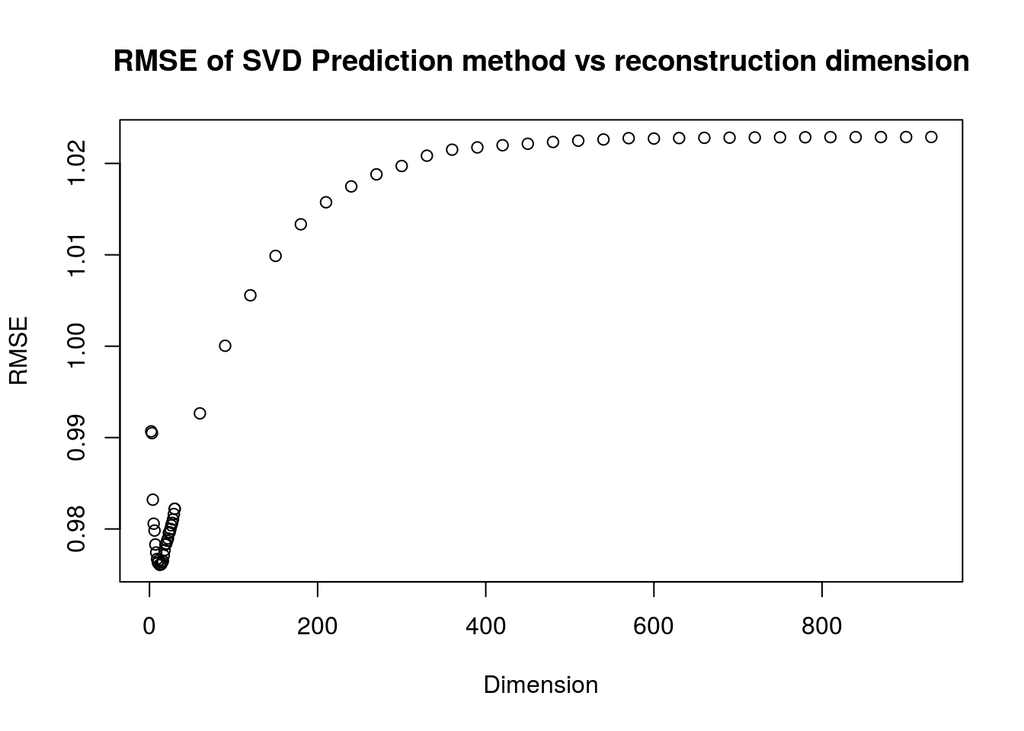

```r
plot(dims, errors$rmse, main="RMSE of SVD Prediction method vs reconstruction dimension", ylab="RMSE", xlab="Dimension")
```

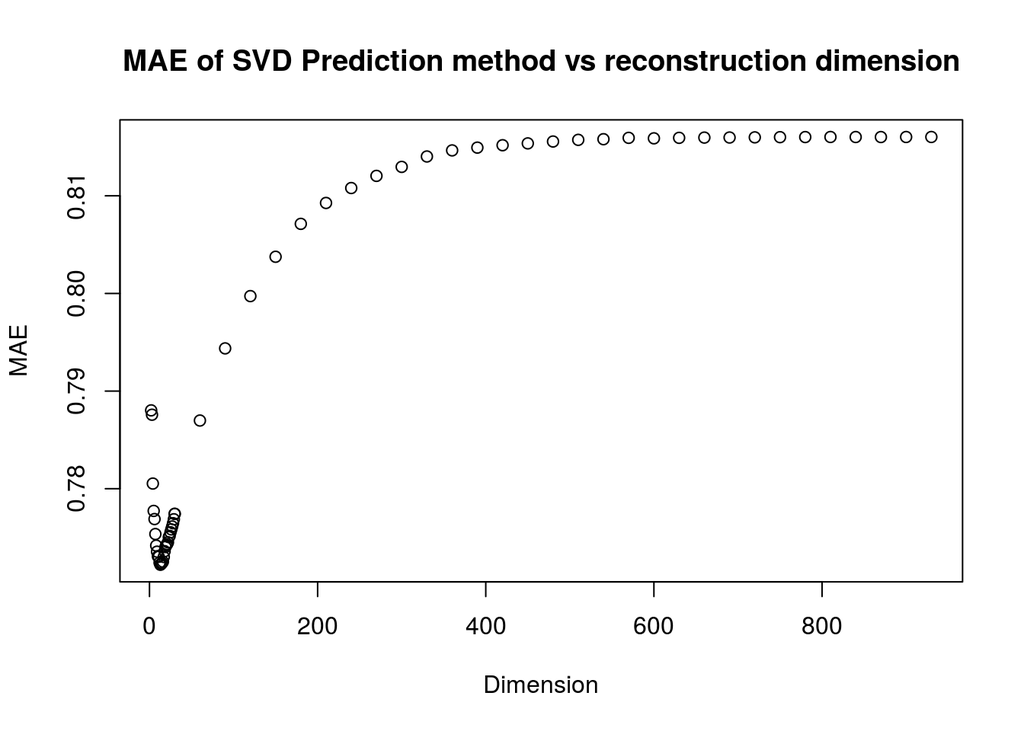

```r
plot(dims, errors$abs, main="MAE of SVD Prediction method vs reconstruction dimension", ylab="MAE", xlab="Dimension")
```

Ainsi la Cross Validation nous permet d’établir que le meilleur modèle de prédiction est celui obtenu avec une dimension de 13 à la fois au sens de l’erreur RMSE que MAE. L’erreur RMSE est de 0.9758 est MAE de 0.7721, ce qui est meilleur que les résultats des approches naïves implémentées à la première question.

Par ailleurs, on constate que l’erreur du modèle (RMSE et MAE) tend vers l’erreur obtenue par la méthode naîve (moyenne des ratings des items) : c’est normal. Lorsque la dimension tend vers sa dimension maximale, on reconstruit alors parfaitement la matrice initiale … qui contenait (pour les ratings à prédire) les moyennes des ratings des items correspondant !

## 7. Comparaison de la méthode SVD avec une approche collaborative de type item-item

Pour cette question, nous avons choisi l’approche implémentée pour le TP1 qui fonctionnait le mieux : l’approche item-item basée sur la distance euclidienne pour determiner le voisinage des items et les poids cosinus (distance cosinus) pour le calcul pondéré des votes prédits.

Dans un premier temps, nous avions essayé de rendre le code et les calculs les plus compacts possibles mais les erreurs retournées par l’algorithme n’étaient pas cohérentes. Dans un second temps, nous avons tenté une autre approche et remplacé une partie de ce code par 1 boucle for pour calculer :

- pour chaque observation du test set, le vote prédit par l’approche ainsi que l’erreur quadratique et absolue de la prédiction

Ceci a pour effet de réduire considérablement la proportion de prédictions effectives de l’approche item-item seule : seuls les votes “surs” sont prédits. La méthode prenant un certain temps à s’executer, elle ne s’execute pas par défaut dans notre code.

```r
cv_item_nn <- function(m, n_fold, observations, n_neighbors) {

  n_obs <- nrow(observations)
  fold_size = n_obs %/% n_fold
  mae <- 0.0
  rmse <- 0.0

  # Compute and na indices a
  na_obs <- which(is.na(m), arr.ind=TRUE)

  m.0s <- m
  m.0s[is.na(m)] <- 0.0

  # Compute matrix of common votes
  print("Computing common votes matrix...")
  movies.commonvotes <- ((t(m.0s) >= 1) + 0) %*% ((m.0s >= 1) + 0)
  diag(movies.commonvotes) <- rep(0,ncol(m))

  for (k in seq(0, n_fold-1)) {

    print(paste("Computing Error for test set ", toString(k+1)))
    test_obs <- observations[seq(k*fold_size, ((k + 1) * fold_size - 1)),]
    train_obs <- observations[-seq(k*fold_size, ((k + 1) * fold_size - 1)),]

    # Construct train matrix (filled with NAs or 0s)
    m_train <- m
    m_train[test_obs] <- NA
    m_train.0s <- m.0s
    m_train.0s[test_obs] <- 0.0

    # Compute columns average
    cM <- colMeans(m_train, na.rm=TRUE)

    # Compute distance matrix and commonvotes matrix with 0s diagonal
    print("Computing distance matrix...")
    dist_mat <- as.matrix(dist(t(m_train))) # on NAs matrix to get exact distance

    # Construct cosinus weights matrix with 0s on diagonal
    print("Computing cosinus weights matrix...")
    m_train.cos <- cosinus.m(m_train.0s) #on 0s matrix to avoid propagating NAs
    diag(m_train.cos) <- 0.0 #

    # Set all weights m_train.cos[i1,i2] to 0 if i2 doesn't belong to i1 NN
    print("Reducing non neighbors cosinus weights matrix to 0...")
    for (movie in seq(1,ncol(m))) {
      dist_vector <- dist_mat[, movie]
      dist_vector[which(movies.commonvotes[, movie] < 3)] <- 10000 # set all distances between movie and i to 10000 if less than 4 common votes
      dist_vector <- sort(dist_vector)
      m_train.cos[tail(names(dist_vector), n=-n_neighbors), movie] <- 0.0
    }
    m_train.cos[is.na(m_train.cos)] <- 0.0 # cosinus.mm fct could have introduced NAs values resulting from 0 division

    # Compute MAE and RMSE for all observations
    n_pred_vote <- 0
    for (j in c(1:nrow(test_obs))) {
      user <- test_obs[j,1]
      item <- test_obs[j,2]
      # Compute 0/1 vector with 1 for item NN
      item.nn_movies <- ifelse(m_train.cos[,item] > 0,1,0)
      # Compute 0/1 vector for item user has voted for in train set
      user.votes <- ifelse(m_train.0s[user,] > 0,1,0)
      user.nnmovies_rated <- user.votes %*% item.nn_movies # the number of movies in item nn our user has given rating
      if (user.nnmovies_rated >= 2) {
        n_pred_vote <- n_pred_vote + 1
        pred_vote <- (m_train.0s[user,] %*% m_train.cos[,item])[1,1]
        pred_vote <- pred_vote/(user.votes %*% m_train.cos[,item])
        mae <- mae + abs(m.na[user,item]-pred_vote)
        rmse <- rmse + ((m.na[user,item]-pred_vote)^2)

      } else if (!(is.na(cM[item]))) {
        n_pred_vote <- n_pred_vote + 1
        pred_vote <- cM[item]
        mae <- mae + abs(m.na[user,item]-pred_vote)
        rmse <- rmse + ((m.na[user,item]-pred_vote)^2)
      }


    }
    mae <- mae/n_pred_vote
    rmse <- sqrt(rmse/n_pred_vote)
  }
  mae <- mae/n_fold
  rmse <- rmse/n_fold
  return(list(mae_er=mae, rmse_er=rmse))
}

#colfilter_errors <- cv_item_nn(m.na, 5, indices, 20)
```

Les performances de cette approche sont 0.215 (RMSE) et 0.169 (MAE). Ce résultat est très etonnant et indique probablement une erreur persistante dans le code. Environ 1/4 des votes seulement ont pu être prédit en moyenne par l’approche collaborative filtering et cette configuration (le reste des prédictions est la moyenne des votes des items). Il est probable que cette approche soit meilleure que l’approche SVD pour les votes prédits “surs” qu’elle produit et moins bonne pour les autres votes prédits (par la moyenne des items).

Par ailleurs, certains paramètres de notre implémentation influencent très certainement les résultats de la prédiction (nombre minimal de vote en commun pour les voisinages, etc.). Ils pourraient également être sujet à une optimisation par validation croisée mais nous n’avons pas réalisé cela ici.